# Hate in Context

Week 1: Defining Hate Crime · LENS preview

Violeta Haas

Department of Political Science

School of Social Sciences and Philosophy

Trinity College Dublin

# Today

1. **Part I** — What is a hate crime?
2. **Part II** — Underrecording & underreporting
3. **Part III** — Why hate crimes are different

# Part I — What is a hate crime?

## Activity: build a definition

1. Find your group: **1=♥** · **2=♦** · **3=♣** · **4=♠**
2. Draft a short definition of hate crime
   - Submit via TCDpolls: Blackboard → Week 01 → Hate Crime Definitions
   - Start your answer with your symbol
   - 8–10 minutes
   - There are no wrong or right answers

## Your Hate Crime Definitions

- Was it hard to agree?
- What was the smallest common denominator?
- How policy-applicable is your definition?

[Let’s take a look at your definitions!](https://tcdpolls.vevox.com/#/meeting/951599/polls)

# Official Definitions

## Police/Legal numbers look comparable…

**Ireland · Garda**

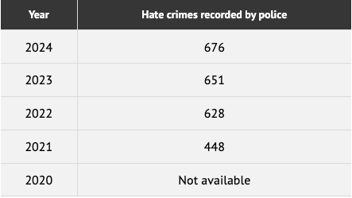

**Germany · BKA**

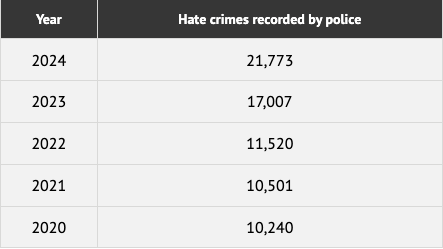

**United States · FBI**

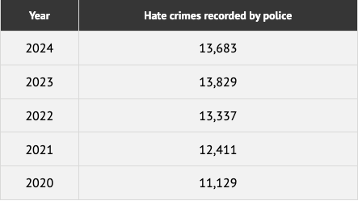

**Spain · Código Penal**

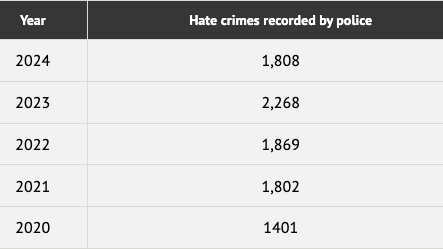

Source: [hatecrime.osce.org](https://hatecrime.osce.org/) (police-recorded)

## …but definitions disagree

shared distinctive

|  | Ireland · Garda | Germany · BKA | United States · FBI | Spain · Código Penal |
| --- | --- | --- | --- | --- |
| Act | criminal offence *and* incidents | criminal offence | criminal offence | criminal offence |
| Characteristics* | + age | + social status, appearance | — | + ideology, *aporophobia*, illness, age |
| Group status | actual or perceived | actual or perceived | actual or perceived | actual or perceived |

* **In common:** race / ethnicity, religion, disability, sexual orientation, gender (identity)

| Label | Typical emphasis |
| --- | --- |
| **Hate crime** | Criminal act + bias motivation / protected characteristic |
| **Hate speech** | Expression; legal and platform thresholds vary widely |
| **Hate incident** | Broader recording (often police / civil society); not always charged |

## Scholars add dimensions…

> It involves acts of violence and intimidation, usually directed toward already stigmatized and marginalized groups. As such, it is a mechanism of power, intended to reaffirm the precarious hierarchies that characterize a given social order. It attempts to recreate simultaneously the threatened (real or imagined) hegemony of the perpetrator’s group and the “appropriate” subordinate identity of the victim’s group.

Perry (2001: 10), in Perry (2014)

## …but also disagree

> …the foundations of much hate crime policy and scholarship have been built on the assumption that these are exclusively “majority versus minority” crimes. However well-intentioned, such an assumption fails to account for the acts of hate, prejudice and bigotry committed by minorities against fellow minorities, or indeed against those who might be described as majority group members.

Chakraborti (2014: 19)

## …and do not reflect police categories

**Germany · BKA**

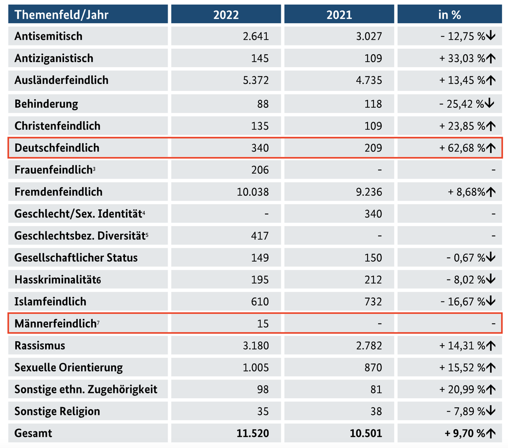

**United States · FBI**

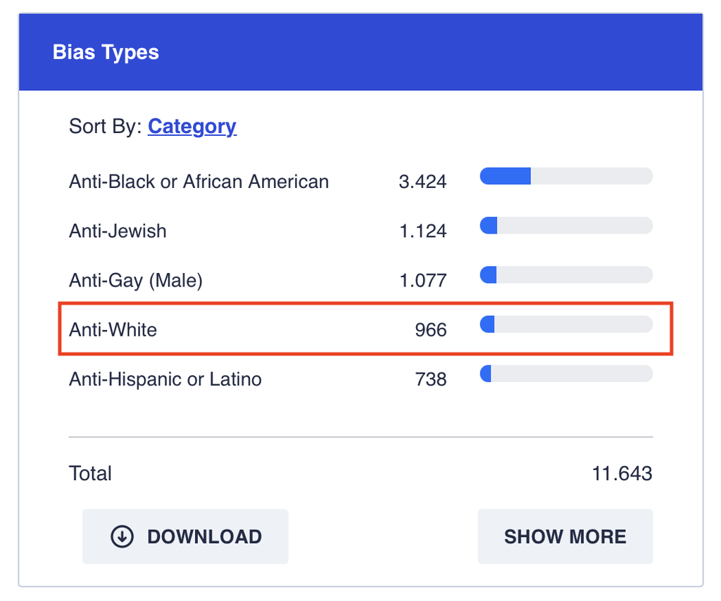

## So what?

- **You** disagree
- **Police/Law** disagree, on type of act and protected characteristics
- **Scholars** disagree, on power, hierarchy, and who counts as a victim

**What this means**

→ every paper needs a definition and a generalizability-statement

→ also means we will see **hardly any comparative cross-country work** in this course

# Part II — Underrecording & underreporting

## Rising acceptance

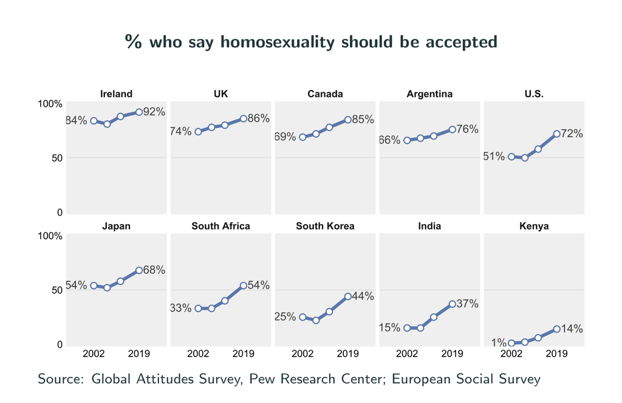

## …yet hate crime rises

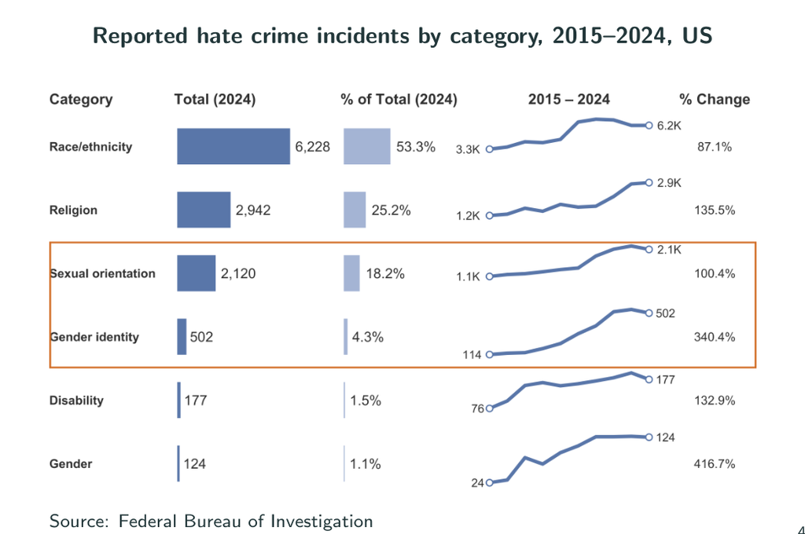

## Who records hate crime?

Actors involved in hate crime data collection:

- Law enforcement agencies
- Federal agencies
- (Regional) government agencies
- Human rights organizations
- Community-based organizations & activists
- Research institutions
- Online platforms and technology companies

## Two different problems

### Under**reporting**

Victims (or witnesses) never tell the police / survey / platform

[discussed in class]

### Under**recording**

The event is known, but not flagged as hate crime

[discussed in class]

## So when we see rising trends…

It might mean more violence — **or**:

[discussed in class]

# Part III — Why hate crimes are different

## Effects beyond the immediate victim

Why treat hate crimes different from otherwise similar non-bias offences?

- Affect the **immediate victim**
- Send message to the victim’s **(perceived) community**
- Impair **intergroup relations**
- Question **democratic values** (inclusion, equity, justice)

# Outlook

## Disclaimer: Two families of explanation

### Individual-level

Psychological traits & offender behaviour

Cognitive and affective processes that drive perpetrators to commit hate crime

### Contextual

Would-be perpetrators’ social environment

Political, cultural, sociological, and economic conditions that make bias-motivated violence more or less likely

## Next week: demographic change

**Week 2** (Mon 21 / Wed 23 Sep) — demographic change and hate crime.

**Required readings**

- Cikara, M., Fouka, V., & Tabellini, M. (2022). Hate crime towards minoritized groups increases as they increase in size-based rank. *Nature Human Behaviour*, 6(11), 1537–1544.
- Hangartner, D., Dinas, E., Marbach, M., Matakos, K., & Xefteris, D. (2019). Does exposure to the refugee crisis make natives more hostile? *American Political Science Review*, 113(2), 442–455.
- Dancygier, R., Egami, N., Jamal, A., & Rischke, R. (2022). Hate crimes and gender imbalances: Fears over mate competition and violence against refugees. *American Journal of Political Science*, 66(2), 501–515.

Weekly comments start (due **Sunday 20 Sep, 11:59 pm**).

## Reminder: position-paper sign-up

- Blackboard **Groups** — one week only; max **3** students per week
- Closes **Friday 18 September 2026, 11:59 pm**
- Paper due Sunday 11:59 pm before that week’s Monday seminar

# Questions?

# Goodbye!

See you Monday — Week 2.